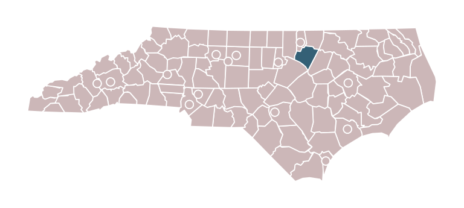

# Franklin County, Spring 2026

## Payments

**Franklin County** is set to receive approximately **$6.04M** in opioid settlement funds from 2022 through 2038. They have received **$1.8M** to date with **$4.25M** more anticipated.

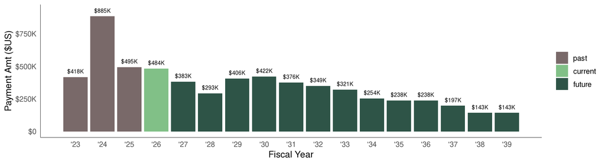

## Spending Plans

**Franklin County** has approved and shared **5** spending plans, authorizing **7** unique strategies.

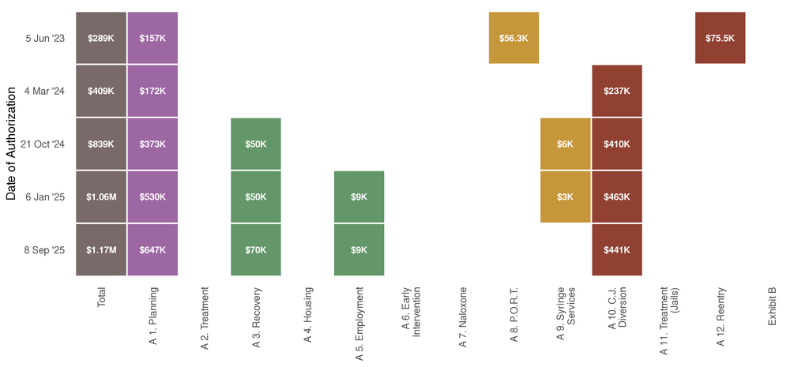

Local governments must approve and share **spending plans** before spending opioid settlement funds. Local governments may not spend more than the approved amounts (although they may spend less). Exhibit A strategies are high-impact strategies for addressing the opioid overdose epidemic; Exhibit B strategies are from the national settlement agreements and are available to local governments after participating in a Collaborative Strategic Planning process.

See all of [Franklin County’s spending authorizations](https://p3-repo-dept-core-nc.apps.cloudapps.unc.edu/?govt=Franklin,county&doc_type=auth) in the Document Library.

## Collaborative Strategic Planning Reports and Recommendations

Local govenments that wish to spend opioid settlement funds on any Exhibit B strategies must first engage in the Collaborative Strategic Planning process, resulting in a report and recommendations document submitted to the local governing board. This process is not required before authorizing spending on Exhibit A strategies.

**Franklin County** has not submitted any report and recommendations documents.

## Past Spending

As of Summer 2025, **Franklin County** has spent **$759K** on **2** ** Exhibit A strategies ** and no Exhibit B strategies (see plot to right).

**Franklin County** has spent the most on **Collaborative Strategic Planning** and **Criminal Justice Diversion Programs** .

As a state, **North Carolina** has spent a total of **$70.7M** ; the top three most-funded strategies are **Recovery Support Services** ( 56 gov’ts, $19.6M ), **Evidence-Based Addiction Treatment** ( 39 gov’ts, $8.64M ), and **Post-Overdose Response Team** ( 36 gov’ts, $8.08M ).

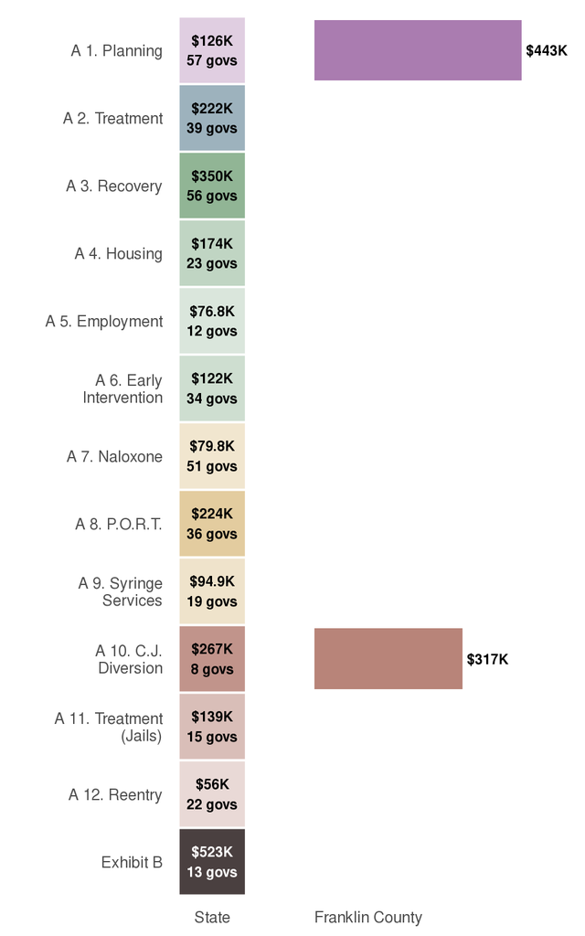

Spending through Summer 2025

This plot averages spending only over governments that have reported spending money on a given strategy. For example, Franklin County has spent $443K on Collaborative Strategic Planning. Statewide, governments have reported funding Collaborative Strategic Planning; the average amount spent between those governments is $126K. This comparison is for informational purposes only, and is not meant to imply any sort of judgement about or relative ranking between settlement-funded programs throughout the state. Comparisons like these often have limited meaning because of the vastly different circumstances in different areas of North Carolina.

## Annual Settlement Update

### Narratives and Success Stories

You can read all of [Franklin County’s progress narratives and success stories](https://p3-repo-dept-core-nc.apps.cloudapps.unc.edu/?govt=Franklin,county&doc_type=narrative) in the Document Library.

### Implementation Scale

Local governments are at varying stages of implementing opioid settlement strategies. For each funded strategy, local governments were asked to selec their State of Implementation from a list of 5 options:

- Exploration and Planning
- Preparation
- Initial Implementation
- Full Implementation
- Further Expansion

Below is the most-advanced stage that **Franklin County** has reported for each funded strategy:

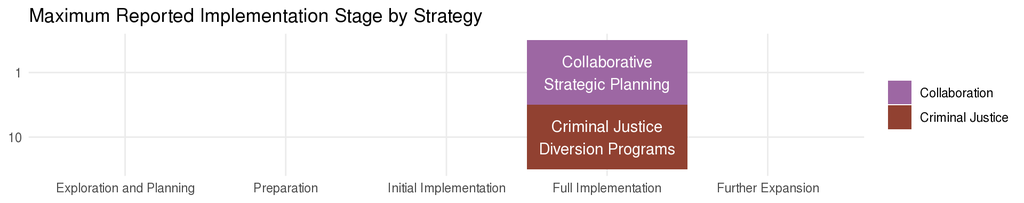

## Local Contacts

**Meredith Wester** , Director of Programs  
Franklin County Sheriff’s Office  
mwester@franklincountync.gov  
[Franklin County website](https://www.franklincountync.gov/)